# Erros Inatos do Metabolismo no SUS

Microdados do DATASUS · CID-10 E70–E90 + triagem neonatal · SIA · SIH · SIM · SINASC · 2010–2025

**Última atualização do painel:** 25 de outubro de 2026 · Notas de lançamento — o que mudou, o que estava errado e por quê.

Os **Erros Inatos do Metabolismo (EIM)** são um grupo **grande e heterogêneo** de doenças genéticas raras — aminoacidopatias, acidúrias orgânicas, doenças de depósito lisossômico (MPS, Gaucher/Fabry/Pompe), distúrbios do ciclo da ureia, glicogenoses, entre muitas outras — em que a **triagem neonatal precoce** (teste do pezinho) e o **tratamento específico** (dieta, terapia de reposição enzimática) mudam radicalmente o prognóstico. Não há uma **fonte censitária de prevalência**; caracterizamos o grupo triangulando **quatro fontes** do DATASUS — **SIA-PA** (ambulatorial), **SIH-RD** (internações), **SIM-DO** (mortalidade) e **SINASC** (nascidos vivos, denominador de incidência) — no período **2010–2025** (SIM definitivo até **2024**). A definição de caso **não é um CID único** (como em doenças de código próprio): usa uma **lookup** de prefixos CID-10 (`scripts/eim_lookup.R`) com camadas *core*, *limítrofe* e *envelope*.

2.472.113

registros ambulatoriais (SIA, core)

79.407

AIH com EIM principal (SIH, core)

85.640

AIH com EIM (core) em qualquer campo (SIH)

6.518–46.966

óbitos por EIM (SIM, causa básica: core–teto, 2010–2024)

1,70/100k NV

mortalidade infantil por EIM (2010–2024)

**Sobre o KPI “SIA, core”.** 2.472.113 registros inclui 526.540 de triagem **fora do capítulo E70–E90** (hipotireoidismo congênito + hiperplasia adrenal congênita) — coerente com a lookup, mas não é só CID E70–E90. Ver composição completa em Ambulatorial. O sabor “qualquer campo” do SIH acima já é restrito à camada core; o total bruto do recorte (todas as camadas, incluindo envelope e triagem) é maior e está detalhado em Internações.

**Como ler estes números.**

- São indicadores de **detecção, uso de serviço e mortalidade registrada** — **não de prevalência**. Os EIM não têm fonte censitária.
- As bases medem coisas distintas e **NÃO se somam** — o mesmo indivíduo pode aparecer em várias, e cada base filtra por uma janela seletiva (SIA = crônicos acompanhados; SIH = descompensações/terapia de reposição enzimática; SIM = letais precoces).
- **EIM é um grupo heterogêneo**: não interpretar um “total de EIM” como uma doença única; cada traçadora tem história natural própria.
- **Detecção ≠ prevalência**; a variação geográfica reflete em grande parte **acesso e oferta de serviços/triagem**, não incidência da doença.
- Aplicamos **supressão de N<5** (LGPD; regra estrutural em doença rara) nas taxas divulgadas. Rótulos CID-10 de 4 caracteres e valores de incidência da literatura marcados `[VERIFICAR]`.
- **Denominador populacional anual**: Projeções da População do IBGE (Revisão 2024), uma única série de 2010–2025 ancorada no Censo 2022 — sem degrau entre fontes (Censo 2010 → projeção → Censo 2022). As taxas padronizadas usam a estrutura etária de 2022 como padrão.

Método e limitações: `plano_analise_EIM_datasus.md` e `RESULTADOS_PRELIMINARES.md`.

## Triangulação das três bases (core, 2010–2025)

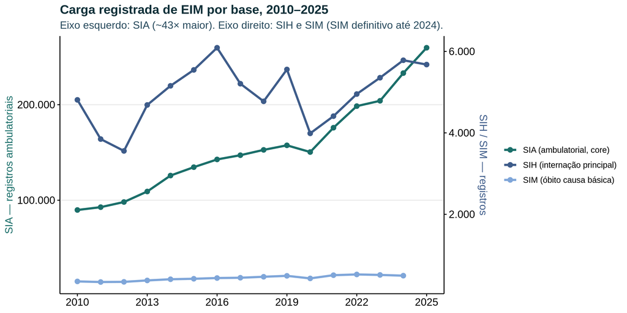

As bases **divergem**, e essa divergência é o achado. Na série 2010–2025, o ambulatorial (SIA) está **em alta** (+6,2%/ano, IC95% +5,5 a +6,9) — reflexo sobretudo de **aumento de detecção, expansão da triagem e incorporação de terapias**, não necessariamente de mudança de incidência. As internações (SIH) estão **sem tendência sustentada** (+0,7%/ano, IC95% −0,7 a +2,2): a série é dominada pelas infusões de TRE e pelo vale da pandemia. A **mortalidade registrada (SIM)** está **em alta** (+2,4%/ano, IC95% +1,8 a +3,1; 0,19 (2010) → 0,17 (2012, mín.) → 0,25 (2022, máx.) → 0,23 (2024) por 100 mil padronizada; ver Mortalidade), crescendo bem menos que a detecção — padrão compatível com expansão de rastreio somada a melhor reconhecimento do EIM na declaração de óbito, e não com aumento de incidência.

**Cautelas desta série.**

- **A pandemia é um vale, não um ano-base.** Com a série desde 2010, 2020 aparece como queda pontual em relação a 2019 (SIA −4,5%, SIH −28,2%, SIM −12,9%), e a retomada a partir de 2021 não se confunde com tendência. Sem 2020–2022, as tendências quase não mudam (SIA +6,4%/ano, IC95% +5,8 a +6,9; SIH +1,3%/ano, IC95% −0,1 a +2,6; SIM +2,4%/ano, IC95% +1,8 a +3,1).
- O **diagnóstico secundário** muda de campo na AIH em 2014–2015 (DIAG_SECUN → DIAGSEC1–9) e seu preenchimento cresce ao longo da série, o que infla sozinho o indicador “EIM em qualquer campo”; no SIA o CID secundário praticamente some a partir de 2015. As séries usam o diagnóstico **principal**.
- O SIM é a base de melhor **cobertura e completude** — o que **não** é o mesmo que melhor **validade da definição de caso** (ver as limitações em Mortalidade).
- As três séries **não são comensuráveis**: o SIA conta **registros de produção**, não pessoas (~2,2–87,8 registros de APAC por paciente nos subgrupos com APAC, ver Ambulatorial), enquanto SIH conta AIH e SIM conta pessoas. O eixo duplo do gráfico é uma conveniência de escala, **não** uma equivalência.

## Onde a mortalidade por EIM é maior — taxa padronizada por UF

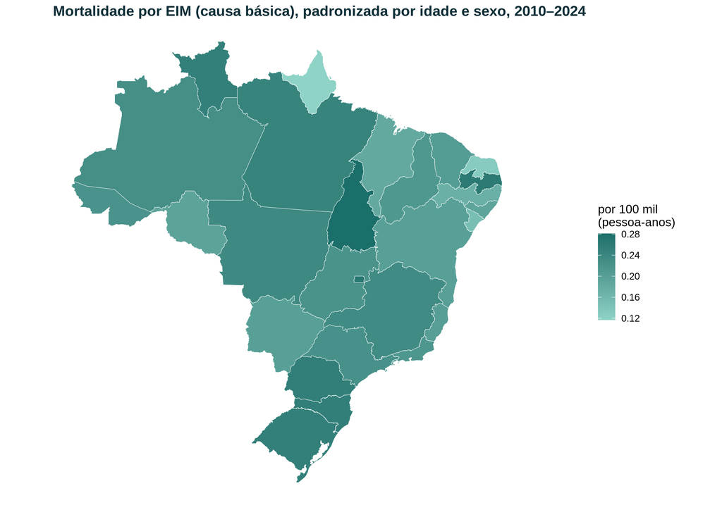

A mortalidade nacional por EIM como causa básica foi de **0,23/100 mil em 2024** (tendência em alta em 2010–2024, +2,4%/ano, IC95% +1,8 a +3,1); a variação por UF combina **incidência, acesso a diagnóstico/tratamento e qualidade de codificação** da declaração de óbito — leia como mortalidade **registrada**, não risco populacional puro. O mapa é por **UF de residência** e **não** tem suavização espacial: em evento raro, as UF de população pequena (AC, RR, AP) oscilam por ruído amostral. Detalhes em Mortalidade (SIM).

## Navegação

- **Ambulatorial (SIA)** — core vs envelope (bracketing), traçadoras, detecção padronizada por UF.
- **Internações (SIH)** — dois sabores (principal vs qualquer campo), peso das MPS/TRE, permanência.
- **Mortalidade (SIM)** — eixo central: mortalidade padronizada e infantil, incidência ao nascimento por traçadora.
- **Teste do pezinho** — painel completo (tradicional PNTN + expandido, Lei 14.154/2021), EIM e não-EIM.
- **Notas de lançamento** — changelog auditado: cada número que mudou, o valor antigo, o valor atual e a razão da correção.